# Decision Tree using caret in R.

#### Let’s create out model!

# Creating the model

```r
df1 = select(df, -X, -Job)

# Splitting train and test samples

set.seed(100)
inTrain = createDataPartition(df1$Risk, p = 0.7, list = F)

train = df1[inTrain, ]
test = df1[-inTrain, ]
```

We’ll create the same model with three different resampling methods and check which is better.

```r
# Bootstrapp resampling method:
control = trainControl(method = 'boot', number = 25)

# Creating the model 1:
set.seed(80)
model1 = train(Risk ~ ., data = train, method = 'rpart', trControl = control)
model1
```

```
## CART
##
## 700 samples
##   8 predictor
##   2 classes: 'bad', 'good'
##
## No pre-processing
## Resampling: Bootstrapped (25 reps)
## Summary of sample sizes: 700, 700, 700, 700, 700, 700, ...
## Resampling results across tuning parameters:
##
##   cp          Accuracy   Kappa
##   0.01111111  0.6894460  0.17474439
##   0.02857143  0.7017854  0.11908511
##   0.04047619  0.7027624  0.09826609
##
## Accuracy was used to select the optimal model using the largest value.
## The final value used for the model was cp = 0.04047619.
```

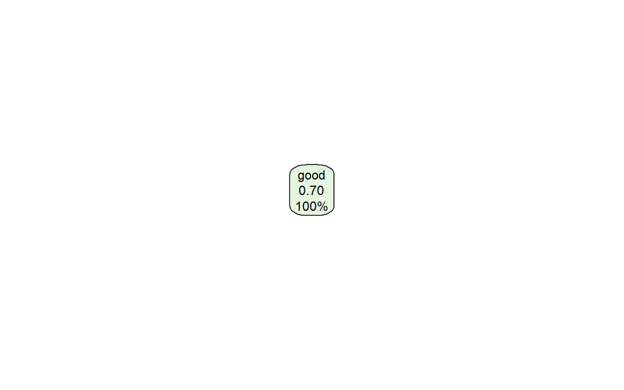

```r
# Tree created

rpart.plot(model1$finalModel)
```

```r
# Cross-Validation resampling method:
control = trainControl(method = 'cv', number = 10)

# Creating model 2:
set.seed(80)
model2 = train(Risk ~ ., data = train, method = 'rpart', trControl = control)
model2
```

```
## CART
##
## 700 samples
##   8 predictor
##   2 classes: 'bad', 'good'
##
## No pre-processing
## Resampling: Cross-Validated (10 fold)
## Summary of sample sizes: 630, 630, 630, 630, 630, 630, ...
## Resampling results across tuning parameters:
##
##   cp          Accuracy   Kappa
##   0.01111111  0.7200000  0.21738643
##   0.02857143  0.7128571  0.13292981
##   0.04047619  0.6928571  0.05810254
##
## Accuracy was used to select the optimal model using the largest value.
## The final value used for the model was cp = 0.01111111.
```

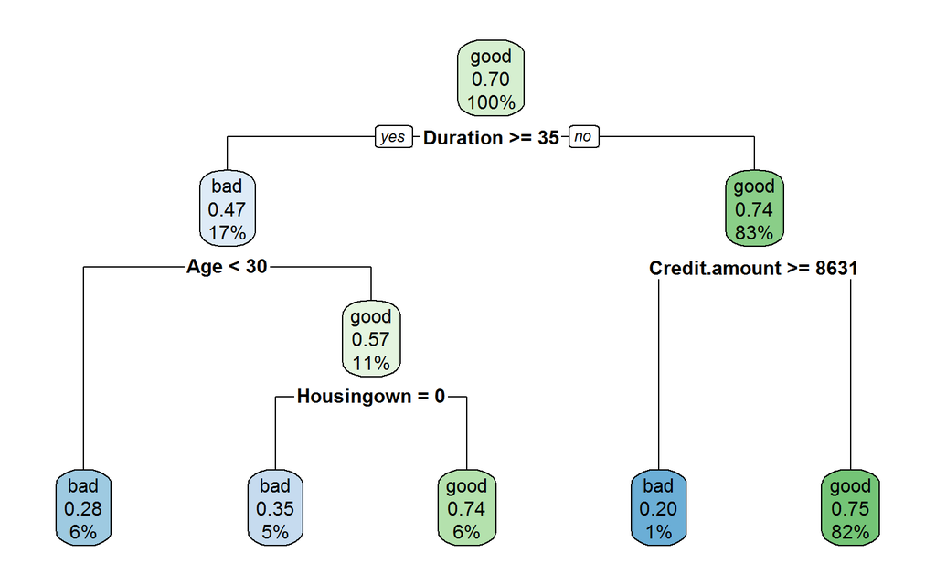

```r
# Tree created
rpart.plot(model2$finalModel)
```

```r
# Repeated k-fold Cross-Validation resampling method:
control = trainControl(method = 'repeatedcv', number = 5, repeats = 10)

# Creating model 3:
set.seed(80)
model3 = train(Risk ~ ., data = train, method = 'rpart', trControl = control)
model3
```

```
## CART
##
## 700 samples
##   8 predictor
##   2 classes: 'bad', 'good'
##
## No pre-processing
## Resampling: Cross-Validated (5 fold, repeated 10 times)
## Summary of sample sizes: 560, 560, 560, 560, 560, 560, ...
## Resampling results across tuning parameters:
##
##   cp          Accuracy   Kappa
##   0.01111111  0.7001429  0.18839031
##   0.02857143  0.7088571  0.13789958
##   0.04047619  0.6982857  0.06785114
##
## Accuracy was used to select the optimal model using the largest value.
## The final value used for the model was cp = 0.02857143.
```

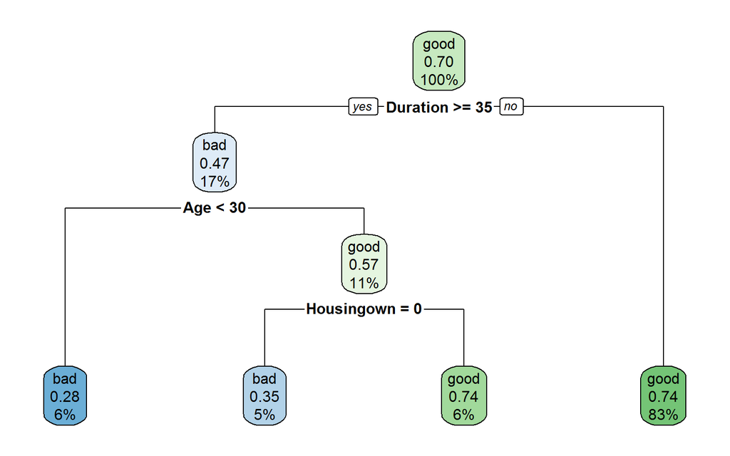

```r
# Tree created
rpart.plot(model3$finalModel)
```

```r
# Testing the model 1:

prev = predict(model1, test)

confusionMatrix(prev, test$Risk)
```

```
## Confusion Matrix and Statistics
##
##           Reference
## Prediction bad good
##       bad    0    0
##       good  90  210
##
##                Accuracy : 0.7
##                  95% CI : (0.6447, 0.7513)
##     No Information Rate : 0.7
##     P-Value [Acc > NIR] : 0.5284
##
##                   Kappa : 0
##
##  Mcnemar's Test P-Value : <2e-16
##
##             Sensitivity : 0.0
##             Specificity : 1.0
##          Pos Pred Value : NaN
##          Neg Pred Value : 0.7
##              Prevalence : 0.3
##          Detection Rate : 0.0
##    Detection Prevalence : 0.0
##       Balanced Accuracy : 0.5
##
##        'Positive' Class : bad
##
```

```r
# Testing the model 2:

prev = predict(model2, test)

confusionMatrix(prev, test$Risk)
```

```
## Confusion Matrix and Statistics
##
##           Reference
## Prediction bad good
##       bad   18   17
##       good  72  193
##
##                Accuracy : 0.7033
##                  95% CI : (0.6481, 0.7545)
##     No Information Rate : 0.7
##     P-Value [Acc > NIR] : 0.4782
##
##                   Kappa : 0.1442
##
##  Mcnemar's Test P-Value : 1.041e-08
##
##             Sensitivity : 0.2000
##             Specificity : 0.9190
##          Pos Pred Value : 0.5143
##          Neg Pred Value : 0.7283
##              Prevalence : 0.3000
##          Detection Rate : 0.0600
##    Detection Prevalence : 0.1167
##       Balanced Accuracy : 0.5595
##
##        'Positive' Class : bad
##
```

```r
# Testing the model 3:

prev = predict(model3, test)

confusionMatrix(prev, test$Risk)
```

```
## Confusion Matrix and Statistics
##
##           Reference
## Prediction bad good
##       bad   15   17
##       good  75  193
##
##                Accuracy : 0.6933
##                  95% CI : (0.6378, 0.745)
##     No Information Rate : 0.7
##     P-Value [Acc > NIR] : 0.6264
##
##                   Kappa : 0.1051
##
##  Mcnemar's Test P-Value : 2.804e-09
##
##             Sensitivity : 0.1667
##             Specificity : 0.9190
##          Pos Pred Value : 0.4687
##          Neg Pred Value : 0.7201
##              Prevalence : 0.3000
##          Detection Rate : 0.0500
##    Detection Prevalence : 0.1067
##       Balanced Accuracy : 0.5429
##
##        'Positive' Class : bad
##
```

```r
results = tibble(Models = c('Model 1', 'Model 2', 'Model 3' ),
                 'Train Accuracy' = c(0.7027624, 0.7200000, 0.7088571),
                 'Test Accuracy' = c(0.7000, 0.7033, 0.6933))
results
```

```
## # A tibble: 3 x 3
##   Models  `Train Accuracy` `Test Accuracy`
##   <chr>              <dbl>           <dbl>
## 1 Model 1            0.703           0.7
## 2 Model 2            0.72            0.703
## 3 Model 3            0.709           0.693
```

As we can see in the table above, the model 2 is the better model. Our model is great predicting ‘good risk’, but very bad predicting ‘bad risk’. Look the tree created in model 1, for example, which classified everything as good risk.

Obs: This is not a good dataset to create predictive models because it’s not balanced, most of the target are ‘good risk’. What would you do to improve de accuracy?